# Univariate Hypothesis Testing

For MATH50XX by ctong

## Import Data

### **Import Data**

Download the end of year HR data file [**eoyHR.xlsx**] from Blackboard.

This Excel workbook contains 2 worksheets:

- **Data:** Data compiled by the HR department of a publishing company
- **Dictionary:** Data dictionary for variables included in the **Data** worksheet

Adapt the following code to import the data into a data frame named `dfHR`. If you have not already installed the `readxl` package, run `install.packages("readxl")` before proceeding.

```r
library (readxl)
dfHR <- as.data.frame(read_excel("eoyHR.xlsx", sheet = "Data"))
head (dfHR) # displays the first few lines of dfHR
```

```
##   City      Education ProfDev HrPay   Income PerfPrev PerfCurr PerfFore Satis
## 1    1 Post-Secondary      No 29.01 52802.20     7.78     7.54     7.86  8.95
## 2    3 Post-Secondary     Yes 27.26 49620.04     5.94     9.66     8.30  9.00
## 3    2      Secondary      No 29.40 53503.69     5.73     6.76     6.35  8.99
## 4    1 Post-Secondary     Yes 27.45 49953.31     5.10     6.19     5.75  9.31
## 5    1      Secondary      No 27.50 50043.81     7.31     7.35     7.93  8.45
## 6    3 Post-Secondary     Yes 30.07 54721.95     7.15     6.86     7.21  8.95
##   BenePrev BeneCurr Action
## 1     3095     4024   None
## 2     2651     3446  Bonus
## 3     1174     1526   None
## 4     3020     3926   None
## 5     1180     1534   None
## 6     3305     4297   None
```

Examine the **Data** list in the **Global Environment** window (typically top right in R-Studio) to confirm that `dfHR` includes 120 observations of 12 variables (i.e., sample size = 120).

## 1-S Test for Mean

### **1-Sample t-Test for Mean**

#### **Test description**

Compares the mean of a variable in a sample against a hypothetical population mean when the population standard deviation is not known.

#### **Assumptions**

- Random sampling from the population
- Independence of observations
- Continuous scale data (i.e., interval or ratio)
- Variable is normally distributed
- No outliers

#### **R syntax**

Let $k$ represent the hypothetical population mean. Let $x$ represent the sample variable (can be a vector or a variable in a data frame).

*2-tailed test*

- $H_0: \mu = k$
- $H_1: \mu \neq k$

`t.test(x, mu = k, alternative="two.sided")`

*1-tailed tests*

- $H_0: \mu \geq k$
- $H_1: \mu < k$

`t.test(x, mu = k, alternative="less")`

- $H_0: \mu \leq k$
- $H_1: \mu > k$

`t.test(x, mu = k, alternative="greater")`

#### **Non-parametric alternative**

The 1-S Wilcoxon Signed Rank test is a non-parametric alternative to the 1-S t-test when the normality assumption is violated. It compares the median of the sample against a hypothesized value.

- `wilcox.test(x, mu = k, alternative="two.sided")`
- `wilcox.test(x, mu = k, alternative="less")`
- `wilcox.test(x, mu = k, alternative="greater")`

#### **Sample analysis**

A business consultant indicated that the average income for sales representatives in the publishing industry is $48795. Do the current incomes at ACME publishing support this claim?

*Identify the null and alternate hypotheses*

Two-tailed test:

$H_0: \mu = 48795$

$H_1: \mu \neq 48795$

*[Optional] Create fresh copy of data frame*

```r
myDF <- dfHR
```

*Visualize the data*

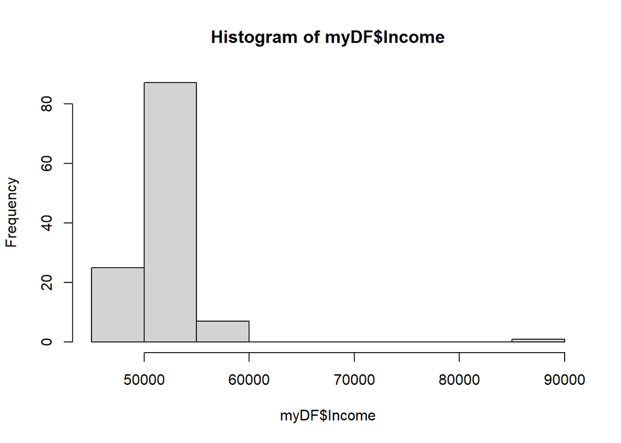

```r
hist(myDF$Income)
```

*Identify outliers*

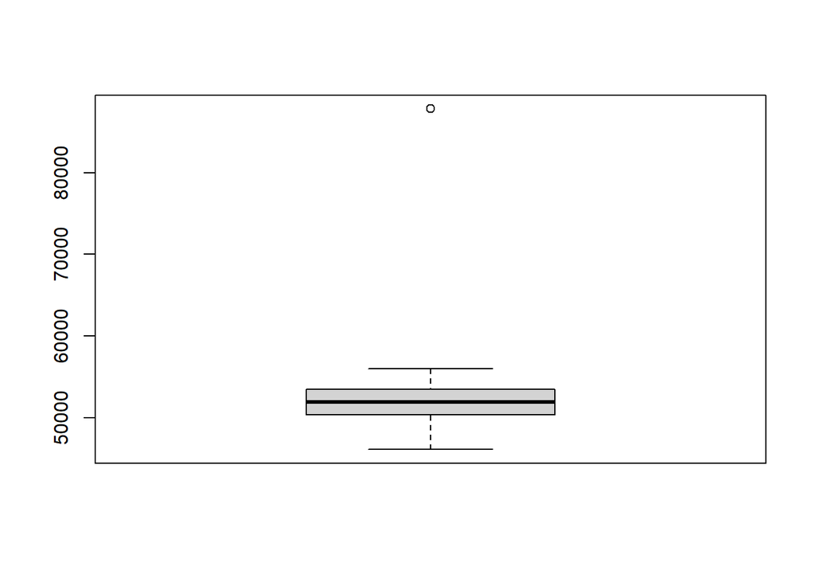

```r
incomeOutliers <- boxplot(myDF$Income)$out
```

```r
incomeOutliers # displays the values stored in incomeOutliers
```

```
## [1] 87808.75
```

The box plot above shows one outlying value of 87808.75, which is now stored in `incomeOutliers`.

*Remove outliers (if appropriate)*

```r
myDF2 <- myDF[!(myDF$Income %in% incomeOutliers),]
```

`myDF2` should contain one fewer observation than `myDF` after removing the outlying observation. Confirm this in the environment window. Then, re-check `myDF2$Income` for outliers.

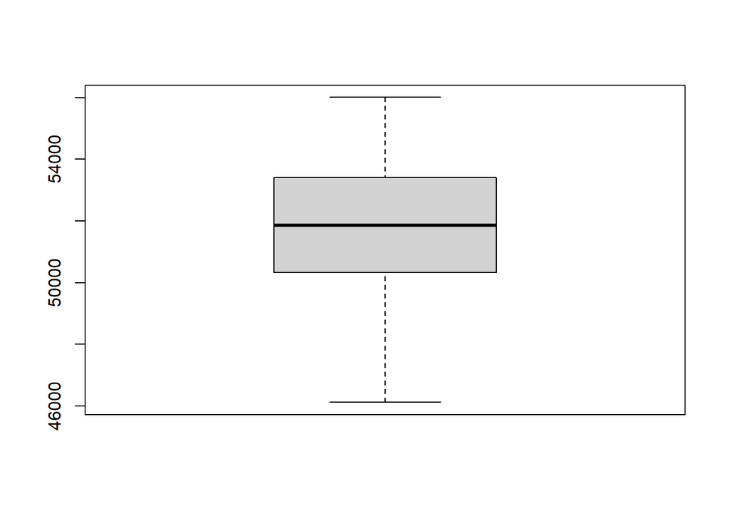

```r
boxplot(myDF2$Income)
```

*Test for normality*

There are several ways to test for a normal distribution. The Shapiro-Wilk normality test is a formal test for the null hypothesis that the variable is distributed normally. It is usually performed at an $\alpha$ of .05. In other words, if the resulting *p* < .05, then we reject the null hypothesis that the variable is distributed normally. If *p* $\geq$ .05, then we conclude that the normality assumption is met.

```r
shapiro.test(myDF2$Income)
```

```
##
##  Shapiro-Wilk normality test
##
## data:  myDF2$Income
## W = 0.98681, p-value = 0.3025
```

*p* $\geq$ .05, $\therefore$ the normality assumption is met.

*Compute summary statistics*

The `describe` function from the `psych` package provides the most common descriptive statistics needed for reporting purposes. Run `install.packages("psych")` first if you have not used this package before.

```r
library (psych)
describe(myDF2$Income)
```

```
##    vars   n     mean      sd   median  trimmed     mad      min      max
## X1    1 119 51789.94 2122.88 51857.95 51865.74 2284.89 46116.49 56007.31
##      range  skew kurtosis    se
## X1 9890.82 -0.31    -0.34 194.6
```

*Perform t-test if assumptions are met*

The question asks whether the sample data supports the claim that the population mean = 48795. It is not a directional claim (i.e., mean < 48795 or mean > 48795), so a 2-tailed test is appropriate.

```r
t.test(myDF2$Income, mu = 48795, alternative="two.sided")
```

```
##
##  One Sample t-test
##
## data:  myDF2$Income
## t = 15.39, df = 118, p-value < 2.2e-16
## alternative hypothesis: true mean is not equal to 48795
## 95 percent confidence interval:
##  51404.57 52175.31
## sample estimates:
## mean of x
##  51789.94
```

*Interpret results*

The question did not explicitly state an $\alpha$ level (also known as the level of significance), so the level of significance will default to the typical .05 level.

The analysis output indicates that *p* < .05, so we reject the null hypothesis that the population mean equals 48795. Therefore, the current incomes at ACME publishing do not support the claim that the average income for sales representatives in the publishing industry is $48795.

*APA-style results*

The current incomes at ACME publishing (*M* = 51789.94, *SD* = 2122.88) suggest that the average income for sales representatives in the publishing industry differs significantly from $48795, *t*(118) = 15.39, *p* < .01.

#### **Analysis notes**

**If the normality assumption was violated**, then the 1-S Wilcoxon Signed Rank test can be performed as a non-parametric alternative.

```r
wilcox.test(myDF2$Income, mu = 48795, alternative="two.sided")
```

```
##
##  Wilcoxon signed rank test with continuity correction
##
## data:  myDF2$Income
## V = 6939, p-value < 2.2e-16
## alternative hypothesis: true location is not equal to 48795
```

When reporting the results of a Wilcoxon test in APA-style, include the median instead of mean and standard deviation. The test statistic produced for a Wilcoxon test varies across software packages, so for the sake of simplicity, you may report the p value on its own (see example below).

A Wilcoxon signed rank test was performed because the data failed to meet the normality assumption. The current incomes at ACME publishing (*Mdn* = 51857.95) suggest that the median income for sales representatives in the publishing industry differs significantly from $48795, *p* < .01.

**If the question asked whether the ACME data suggests that the average income is greater than $48795**, then a 1-tailed (right-tailed) test should be performed using `t.test(myDF2$Income, mu = 48795, alternative="greater")`.

**If the question asked whether the ACME data suggests that the average income is less than $48795**, then a 1-tailed (left-tailed) test can be performed using `t.test(myDF2$Income, mu = 48795, alternative="less")`. Note that this test is unlikely to produce a significant result (i.e., *p* < .05) given that the sample mean of $51789.94 is actually greater than $48795..

## 1-S Test for Proportion

### **1-Sample z-Test for Proportion**

#### **Test description**

Compares a sample proportion against a hypothetical population proportion. A sample proportion refers to the proportion of observations in a sample which falls into a specific category, as defined by a categorical variable.

#### **Assumptions**

The variable of interest must be a categorical variable which identifies whether each observation falls into the specific category of interest.

Let $n$ represent the sample size and $p$ represent the sample proportion.

Let *success* represent observations which fall into the specific category of interest.

Let *failure* represent observations which do not fall into the specific category of interest.

Then:

- Sample size: $n \geq 50$
- Number of successes: $np \geq 5$
- Number of failures: $n(1-p) \geq 5$

#### **R syntax**

Let $k$ represent the hypothetical population proportion. Let $x$ represent the number of successes in the sample. Success refers to the number of observations which falls into the category of interest.

*2-tailed test*

- $H_0: \pi = k$
- $H_1: \pi \neq k$

`prop.test(x, n, p = k, alternative="two.sided", correct = FALSE)`

*1-tailed tests*

- $H_0: \pi \geq k$
- $H_1: \pi < k$

`prop.test(x, n, p = k, alternative="less", correct = FALSE)`

- $H_0: \pi \leq k$
- $H_1: \pi > k$

`prop.test(x, n, p = k, alternative="greater", correct = FALSE)`

**Notes:**

- When `correct` is set to `FALSE`, `prop.test()` carries out a $\chi^2$ (chi-squared) test with degree of freedom of 1, which is mathematically equivalent to the 1-sample z-test for proportions.
- The $\chi^2$ test is a very versatile test with a wide range of applications.

#### **Non-parametric alternatives**

**If $n < 50$:**

The binomial test may be used:

- `binom.test(x, n, p = k, alternative = "two.sided")`
- `binom.test(x, n, p = k, alternative = "less")`
- `binom.test(x, n, p = k, alternative = "greater")`

**If $n \geq 50$, but $np < 5$ or $n(1-p) < 5$**

Use `prop.test()` with the Yates’ continuity correction:

- `prop.test(x, n, p = k, alternative = "two.sided", correct = TRUE)`
- `prop.test(x, n, p = k, alternative = "less", correct = TRUE)`
- `prop.test(x, n, p = k, alternative = "greater", correct = TRUE)`

#### **Sample analysis**

The director of sales at ACME publishing is considering the cancellation of this year’s professional development workshop due to poor attendance last year. She believes that less than 65% of the sales representatives attended last year’s workshop. Does the sample data support this belief at the .01 level of significance?

*Identify the null and alternate hypotheses*

One-tailed test:

$H_0: \pi \geq .65$

$H_1: \pi < .65$

*[Optional] Create fresh copy of data frame*

```r
myDF <- dfHR
```

*Determine n and x*

```r
# table() counts the number of observations that falls into each category of ProfDev, Yes for those who attended the workshop and No for those who did not
pdCounts = table(myDF$ProfDev)
pdCounts
```

```
##
##  No Yes
##  49  71
```

```r
n = sum(pdCounts) # n = sample size = sum of observations across ALL categories of ProfDev
n
```

```
## [1] 120
```

```r
x = pdCounts["Yes"] # x = number of successes = number of Yes
x
```

```
## Yes
##  71
```

*Perform z-test if assumptions are met*

The sample size, number of successes and failures were 120, 71 and 49 respectively. Therefore, all assumptions were met.

```r
prop.test(x,n,p = 0.65, alternative="less", correct=FALSE)
```

```
##
##  1-sample proportions test without continuity correction
##
## data:  x out of n, null probability 0.65
## X-squared = 1.7949, df = 1, p-value = 0.09017
## alternative hypothesis: true p is less than 0.65
## 95 percent confidence interval:
##  0.0000000 0.6626597
## sample estimates:
##         p
## 0.5916667
```

*Interpret results*

The question stated a .01 level of significance, so the `p-value` produced by the analysis should be compared against .01 to determine whether the null hypothesis should be rejected. Note that the sample estimate for proportion is also denoted as `p`, which should not be confused with the `p-value`.

The results indicate that *p* = .09, which is greater than .01. Therefore, we fail to reject the null hypothesis that the 65% or more of the sales representatives attended last year’s workshop. We can not conclude that less than 65% of the sales representatives attended last year’s workshop at a .01 level of significance.

*APA-style results*

59% of the sales representatives in the data sample attended last year’s workshop. However, we can not conclude that less than 65% of the sales representatives attended last year’s workshop at the .01 level of significance, $\chi^2$(1) = 1.79, *p* = .09.

#### **Analysis notes**

**If sample size was less than 50**, the binomial test can be performed instead. This test produces an exact `p-value` using the binomial theorem. There is no intermediary test statistic.

```r
binom.test(x, n, p=.65, alternative="less")
```

```
##
##  Exact binomial test
##
## data:  x and n
## number of successes = 71, number of trials = 120, p-value = 0.1076
## alternative hypothesis: true probability of success is less than 0.65
## 95 percent confidence interval:
##  0.0000000 0.6672771
## sample estimates:
## probability of success
##              0.5916667
```

A binomial test was performed due to the small sample size. 59% of the sales representatives in the data sample attended last year’s workshop. However, we can not conclude that less than 65% of the sales representatives attended last year’s workshop at the .01 level of significance, *p* = .11.

**If sample size was greater than or equal to 50, but the number of successes or failures was less than 5**, apply the Yates’ continuity correction by setting `correct` to `TRUE` in `prop.test()`.